# Expert-informed SDM: data-thinning simulation

Camila Diaz

2026-06-17

# Overview

This document re-uses the two-step Bayesian species distribution model (SDM) for monarch butterfly (*Danaus plexippus*) in Canada explained in the **Expert_informed_SDM.Rmd** and turns it into a data-thinning simulation experiment.

**Step 1: Expert-knowledge model (Stan).** Expert-elicited range limits and point observations define an expert-informed prior and a small occurrence dataset. A logistic model with a triangular suitability response is fit in Stan, and the posterior distributions of the regression coefficients ($\alpha$, $\beta_1$, $\beta_2$) are extracted.

# 1. Setup

```r
library(dplyr)
library(ggplot2)
library(tidyr)
library(sf)
library(INLA)
library(geodata)
library(terra)
```

# 2. Data loading

```r
epsg = 3857
epsg_crs = "EPSG:3857"#Study area - Quebec

# Study area
study_area0 <- st_read("C:/Users/maria/Documents/GitHub/Expert_SDM/data/study_area/canada.shp",
  quiet = TRUE)
study_area <- study_area0 |>
  st_transform(epsg) |>
  st_union()|>
  st_simplify(dTolerance = 1000)|> # 1 km tolerance
  st_make_valid()

# Occurrence data
monarch_data <- st_read("C:/Users/maria/Documents/GitHub/Expert_SDM/data/species/PA_monarch_CAN.shp",
  quiet = TRUE)
monarch_sf0 <- monarch_data |>
  st_transform(crs = epsg)

# Expert knowledge data
ek_pnt <- read.csv("C:/Users/maria/Documents/GitHub/Expert_SDM/data/expert_knowledge/Points.csv")
ek_answrs <- read.csv("C:/Users/maria/Documents/GitHub/Expert_SDM/data/expert_knowledge/Responses.csv")

# Environmental layers - Ouranos
tas_mean0 <- rast("C:/Users/maria/Documents/GitHub/Expert_SDM/data/predictors/tas_mean.tif")
pr_mean0 <- rast("C:/Users/maria/Documents/GitHub/Expert_SDM/data/predictors/pr_mean.tif")
```

Four data sources are loaded and a common projection is fixed:

| Object | Contents |
| --- | --- |
| `study_area` | Canada polygon, dissolved (`st_union`), simplified to 1 km tolerance, and made valid, in EPSG:3857 |
| `monarch_sf` | Full presence/absence occurrence records, reprojected to EPSG:3857 |
| `ek_pnt` | Expert-elicited point locations with label (`presence`/`avoid`) and confidence |
| `ek_answrs` | Expert-elicited range limits for temperature and precipitation (one row per survey response) |
| `tas_mean0`, `pr_mean0` | Mean annual temperature and precipitation rasters (Ouranos climate data) |

EPSG:3857 is used throughout so that all distance-based operations (mesh, simplification) are in metres.

# 3. Environmental layer preparation

```r
tas_mean <- project(tas_mean0, epsg_crs)
tas_mask <- mask(tas_mean, vect(study_area))
mt <- global(tas_mask, mean, na.rm = TRUE)[1,1]
st <- global(tas_mask, sd, na.rm = TRUE)[1,1]
std_tas <- (tas_mask - mt) / st


pr_mean <- project(pr_mean0, epsg_crs)
pr_mask <- mask(pr_mean, vect(study_area))
mp <- global(pr_mask, mean, na.rm = TRUE)[1,1]
sp <- global(pr_mask, sd, na.rm = TRUE)[1,1]
std_pr <- (pr_mask - mp) / sp


env <- c(std_tas, std_pr)
names(env) <- c("temp", "prec")

env
```

```
#> class       : SpatRaster
#> dimensions  : 684, 1499, 2  (nrow, ncol, nlyr)
#> resolution  : 26720.37, 26738.21  (x, y)
#> extent      : -20037506, 20016329, 968774.1, 19257708  (xmin, xmax, ymin, ymax)
#> coord. ref. : WGS 84 / Pseudo-Mercator (EPSG:3857)
#> source(s)   : memory
#> names       :      temp,     prec
#> min values  : -2.487619, -1.91499
#> max values  :  1.973588, 19.33590
```

```r
env_df <- as.data.frame(env, xy = TRUE, na.rm = FALSE)

# Track which cells are non-NA
valid_idx <- complete.cases(env_df[, c("temp", "prec")])
env_valid <- env_df[valid_idx, ]
```

Each raster is reprojected to EPSG:3857, clipped to the study area, then standardised to zero mean and unit standard deviation across the non-NA cells.

This puts temperature and precipitation on a common scale before they enter the model. The means and SDs (`mt`, `st`, `mp`, `sp`) are stored and reused in the next chunk to standardise the expert responses with the *same* transformation, so expert range limits and raster values are directly comparable.

# 4. Expert knowledge processing

```r
# Spatialize expert points
sf_pnt <- ek_pnt |>
  st_as_sf(coords = c("long", "lat"),
           crs = 4326) |>
  st_intersection(study_area0) |>
  st_transform(crs = epsg)
head(sf_pnt, 5)
```

```
#> Simple feature collection with 5 features and 14 fields
#> Geometry type: POINT
#> Dimension:     XY
#> Bounding box:  xmin: -8644652 ymin: 5836324 xmax: -7842596 ymax: 6384225
#> Projected CRS: WGS 84 / Pseudo-Mercator
#>               survey_id                    time point_id     type confidence
#> 1 20260427210652_0c21a5 2026-04-27 18:44:45 UTC        1 presence       High
#> 2 20260427210652_0c21a5 2026-04-27 18:44:45 UTC        2 presence       High
#> 3 20260427210652_0c21a5 2026-04-27 18:44:45 UTC        3 presence     Medium
#> 4 20260427210652_0c21a5 2026-04-27 18:44:45 UTC        4 presence        Low
#> 5 20260427210652_0c21a5 2026-04-27 18:44:45 UTC        5 presence        Low
#>   notes iso3       status colr_cd   name  contnnt           region i_3166_
#> 1        CAN Member State     CAN Canada Americas Northern America      CA
#> 2        CAN Member State     CAN Canada Americas Northern America      CA
#> 3        CAN Member State     CAN Canada Americas Northern America      CA
#> 4        CAN Member State     CAN Canada Americas Northern America      CA
#> 5        CAN Member State     CAN Canada Americas Northern America      CA
#>   frnch_s                 geometry
#> 1  Canada POINT (-8292530 5836324)
#> 2  Canada POINT (-8644652 5934163)
#> 3  Canada POINT (-7842596 6080922)
#> 4  Canada POINT (-8449029 6257033)
#> 5  Canada POINT (-8077344 6384225)
```

```r
sf_pnt <- sf_pnt |>
  mutate(y = as.integer(type == "presence"),
         temp = terra::extract(env$temp, vect(sf_pnt))[,2],
         prec = terra::extract(env$prec, vect(sf_pnt))[,2])
# standarize range values and Keep the necessary columns
answrs_select <- ek_answrs |>
  mutate(std_min_temp = (min.temp - mt) / st,
         std_max_temp = (max.temp - mt) / st,
         std_min_prec = (min.prec - mp) / sp,
         std_max_prec = (max.prec - mp) / sp) |>
  select("survey_id", "std_min_temp", "std_max_temp", "confidence.temp", "std_min_prec", "std_max_prec", "confidence.prec")
```

**Expert points** (`sf_pnt`). The raw CSV coordinates are converted to an `sf` object (WGS84), clipped to the study area, and reprojected to EPSG:3857. The binary response is defined as $y_n = 1$ when the label is `"presence"` and $0$ otherwise, and standardised temperature and precipitation are extracted at each point from the `env` stack.

**Expert range responses** (`answrs_select`). The elicited minimum and maximum temperature and precipitation are standardized with the same $\bar{x}$ and $s_x$ used for the rasters, then the per-covariate columns plus confidence are kept. These standardized limits become the prior centres $a_k^*$, $b_k^*$, $c_k^*$ of the triangular response in Step 1.

# 5. Stan data preparation

Using Stan to run step 1, expert informed model

```r
#library(cmdstanr)
library(posterior)
library(rstan)

sigma_levels <- c(Low = 0.01, Medium = 0.5, High = 1.0)
sigma_levels
```

```
#>    Low Medium   High
#>   0.01   0.50   1.00
```

```r
sigma_temp <- answrs_select$confidence.temp
sigma_prec <- answrs_select$confidence.prec

stan_data <- list(
  N  = length(sf_pnt$y),
  y  = as.integer(sf_pnt$y),
  x1 = sf_pnt$temp,
  x2 = sf_pnt$prec,

  # Covariate 1 expert values + uncertainty
  a1_star = answrs_select$std_min_temp,
  b1_star = answrs_select$std_max_temp,
  c1_star = (answrs_select$std_max_temp/2),
  sigma_a1 = sigma_levels[sigma_temp],
  sigma_b1 = sigma_levels[sigma_temp],
  sigma_c1 = sigma_levels[sigma_temp],

  # Covariate 2 expert values + uncertainty
  a2_star = answrs_select$std_min_prec,
  b2_star = answrs_select$std_max_prec,
  c2_star = (answrs_select$std_max_prec/2),
  sigma_a2 = sigma_levels[sigma_prec],
  sigma_b2 = sigma_levels[sigma_prec],
  sigma_c2 = sigma_levels[sigma_prec],

  # Slope priors (both positive effects expected)
  beta1_mu = 1,
  beta1_sigma = sigma_levels[sigma_temp],
  beta2_mu = 1,
  beta2_sigma = sigma_levels[answrs_select$confidence.prec]
)
```

The Stan input list bundles the expert dataset and the prior hyper-parameters:

- `N`, `y`, `x1`, `x2`: the expert points and their standardized covariates.
- Triangular shape priors per covariate: the expert lower limit $a_k^*$, upper limit $b_k^*$, and implied mode $c_k^* = b_k^*/2$ (standardized units), each with an uncertainty `sigma_*`.
- Slope direction priors (`beta1_mu = 1`, `beta2_mu = 1`) encoding the expectation that warmer/wetter conditions raise occurrence probability.

`sigma_levels` defines three qualitative uncertainty tiers (`low = 0.01`, `medium = 0.5`, `high = 1.0`). A tighter sigma keeps the sampler near the expert-stated value; a wider sigma lets the data move it.

# 6. Step 1: Expert-knowledge model (Stan)

```r
stan_code <- stan_model(file = "Step1-Expert_model.stan")


fit <- sampling(stan_code,
                data = stan_data,
                chains = 4,
                refresh = 0,
                show_messages = FALSE,
                open_progress = FALSE)

print(fit, pars = c("beta1", "beta2"))
```

```
#> Inference for Stan model: anon_model.
#> 4 chains, each with iter=2000; warmup=1000; thin=1;
#> post-warmup draws per chain=1000, total post-warmup draws=4000.
#>
#>       mean se_mean   sd 2.5%  25%  50%  75% 97.5% n_eff Rhat
#> beta1 2.16    0.01 0.36 1.49 1.92 2.15 2.40  2.87  3155    1
#> beta2 1.00    0.00 0.01 0.98 0.99 1.00 1.01  1.02  3821    1
#>
#> Samples were drawn using NUTS(diag_e) at Wed Jun 17 15:46:45 2026.
#> For each parameter, n_eff is a crude measure of effective sample size,
#> and Rhat is the potential scale reduction factor on split chains (at
#> convergence, Rhat=1).
```

## Step 1: prediction function

```r
predict_occurrence <- function(fit, new_x1, new_x2) {

  draws <- as.matrix(fit, pars = c("alpha", "beta1", "beta2",
                                    "a1", "c1", "b1",
                                    "a2", "c2", "b2"))

  tri <- function(x, a, b, c) {
    ifelse(x < a | x > b, 0,
      ifelse(x <= c,
        2 * (x - a) / ((b - a) * (c - a)),
        2 * (b - x) / ((b - a) * (b - c))))
  }

  preds <- sapply(seq_along(new_x1), function(i) {
    f1 <- tri(new_x1[i], draws[, "a1"], draws[, "b1"], draws[, "c1"])
    f2 <- tri(new_x2[i], draws[, "a2"], draws[, "b2"], draws[, "c2"])
    mu <- draws[, "alpha"] + draws[, "beta1"] * f1 + draws[, "beta2"] * f2
    mean(plogis(mu))
  })

  preds
}

preds <- predict_occurrence(fit,
                            new_x1 = env_valid$temp,
                            new_x2 = env_valid$prec)
```

## Step 1: Predicted occurrence map

```r
# Create an empty raster with same extent/resolution
pred_raster1 <- rast(env[[1]])
values(pred_raster1) <- NA

# Fill in predictions at valid cells
pred_raster1[valid_idx] <- preds

non_na_extent1 <- ext(trim(pred_raster1))
pred_cropped1 <- crop(pred_raster1, non_na_extent1)
```

## Step 1: Posterior uncertainty map

```r
predict_sd <- function(fit, new_x1, new_x2) {
  draws <- as.matrix(fit, pars = c("alpha", "beta1", "beta2",
                                    "a1", "c1", "b1",
                                    "a2", "c2", "b2"))
  tri <- function(x, a, b, c) {
    ifelse(x < a | x > b, 0,
      ifelse(x <= c,
        2 * (x - a) / ((b - a) * (c - a)),
        2 * (b - x) / ((b - a) * (b - c))))
  }

  sds <- sapply(seq_along(new_x1), function(i) {
    f1 <- tri(new_x1[i], draws[, "a1"], draws[, "b1"], draws[, "c1"])
    f2 <- tri(new_x2[i], draws[, "a2"], draws[, "b2"], draws[, "c2"])
    mu <- draws[, "alpha"] + draws[, "beta1"] * f1 + draws[, "beta2"] * f2
    sd(plogis(mu))  # <-- sd instead of mean
  })
  sds
}

sd_raster1 <- rast(env[[1]])
values(sd_raster1) <- NA
sd_raster1[valid_idx] <- predict_sd(fit, env_valid$temp, env_valid$prec)

non_na_extent1 <- ext(trim(sd_raster1))
sd_cropped1 <- crop(sd_raster1, non_na_extent1)
```

`predict_sd()` is identical to `predict_occurrence()` except it returns the posterior **standard deviation** of $\hat{p}_i^{(s)}$ across draws instead of the mean, a spatially explicit measure of Step 1 parameter uncertainty. High SD marks cells where covariates sit near the edges of the elicited range or where the coefficients are poorly determined. The result is rasterised and cropped into `sd_cropped1`.

# 7. Step 2: priors from the Step 1 posterior

```r
# Extract mean and SD from Stan posterior to use as INLA priors
stan_fixed <- summary(fit, pars = c("alpha", "beta1", "beta2"),
                      probs = c(0.025, 0.5, 0.975))$summary

# Pull mean and sd for each parameter
prior_alpha_mean  <- stan_fixed["alpha",  "mean"]
prior_alpha_sd    <- stan_fixed["alpha",  "sd"]

prior_beta1_mean  <- stan_fixed["beta1",  "mean"]
prior_beta1_sd    <- stan_fixed["beta1",  "sd"]

prior_beta2_mean  <- stan_fixed["beta2",  "mean"]
prior_beta2_sd    <- stan_fixed["beta2",  "sd"]
```

This is the Bayesian updating. The Step 1 marginal posteriors for the three fixed effects are summarized to a Gaussian approximation, a mean and SD for each of $\alpha$, $\beta_1$, $\beta_2$, which will serve as informative priors in the INLA model.

## Step 2: SPDE mesh, spatial field, and model formula

```r
# Convert SD to precision
prec_alpha <- 1 / prior_alpha_sd^2
prec_beta1 <- 1 / prior_beta1_sd^2
prec_beta2 <- 1 / prior_beta2_sd^2

# Build INLA-format priors from Stan posteriors
prior_alpha <- list(prior = "gaussian",
                    param = c(prior_alpha_mean, prec_alpha))

prior_beta1 <- list(prior = "gaussian",
                    param = c(prior_beta1_mean, prec_beta1))

prior_beta2 <- list(prior = "gaussian",
                    param = c(prior_beta2_mean, prec_beta2))


pedge1 <- 0.01
edge1 <- min(c(diff(st_bbox(study_area)[c(1,3)])*pedge1,diff(st_bbox(study_area)[c(2,4)])*pedge1))


mesh <- inla.mesh.2d(loc.domain = NULL,
                     max.edge = c(edge1,edge1*3),
                     min.angle = 21,
                     cutoff = edge1/1,
                     offset = c(edge1,edge1*3),
                     boundary = study_area,
                     crs = st_crs(study_area))


spde <- inla.spde2.pcmatern(
  mesh  = mesh,
  #prior.range = c(500000, 0.05),
  #prior.sigma = c(1, 0.01)
  prior.range = c(10, 0.05),
  prior.sigma = c(1, 0.05)
)
iset  <- inla.spde.make.index("s", n.spde = spde$n.spde)
formula <- y ~ -1 + intercept + x1 + x2 + f(s, model = spde)
```

```r
# The prediction grid does not depend on the occurrence data, so the projector
# matrix and the prediction stack are built once here and reused for every
# replicate and every removal level.
coords_pred <- as.matrix(env_valid[, c("x", "y")])
A_pred      <- inla.spde.make.A(mesh, loc = coords_pred)

stack_pred <- inla.stack(
  data    = list(y = NA),
  A       = list(A_pred, 1),
  effects = list(iset,
                 data.frame(intercept = 1,
                            x1 = env_valid$temp,
                            x2 = env_valid$prec)),
  tag = "pred"
)

# Non-informative baseline prior, shared across all removal levels.
prior.beta <- list(prec = list(default = 1/(1)^2, Intercept = 1/(20)^2),
                   mean = list(default = 0, Intercept = 0))
```

This chunk and the one above build everything the Step-2 fits share. Like the priors, they are computed once: the mesh, SPDE, index, formula, prediction stack, and non-informative prior do not depend on the occurrence data and are reused unchanged across all four removal levels and all replicates.

# 8. Simulation design

What follows is a data-thinning experiment repeated at four removal levels, **70 %, 90 %, 99 %, and 99.9 %** of the occurrence records deleted. At each level the Step 2 INLA model is fit twice on each thinned dataset:

1. with the **expert-informed** Gaussian priors carried over from Step 1, and
2. with **non-informative** priors.

**Replication to reduce sampling bias.** A single random thinning draw can be lucky or unlucky, especially at 99 % and 99.9 % removal where only a handful of points survive, so any one map partly reflects *which* points happened to remain rather than the effect of data scarcity itself. To average that out, each removal level is run `n_rep` times on independent random subsamples, and the per-cell prediction and posterior-SD maps are averaged across replicates. The averaged map is a Monte-Carlo estimate of the expected result at that removal level, with the replicate-to-replicate noise of any single draw largely cancelled.

Because the mesh, SPDE prior, formula, and prediction grid are held fixed, the only thing that changes between blocks is `removal_pct`. This isolates two effects: how predictions degrade as data become scarce, and how much the Step 1 expert knowledge buffers that degradation. As `removal_pct` rises, the expert-informed maps should stay closer to the Step 1 expectation, while the non-informative maps revert toward the spatial prior mean with inflated posterior SD.

## Function to subsample

```r
# Number of independent thinning replicates averaged at each removal level.
# Each replicate fits two INLA models (expert-informed + non-informative).
n_rep <- 100

random_subsample <- function(data, pct_remove, seed = NULL, verbose = TRUE) {
  stopifnot(pct_remove > 0 && pct_remove < 100)
  if (!is.null(seed)) set.seed(seed)

  n_total  <- nrow(data)
  n_keep   <- round(n_total * (1 - pct_remove / 100))
  keep_idx <- sample(n_total, n_keep, replace = FALSE)

  result <- data[keep_idx, ]

  if (verbose) {
    cat("=== Random subsampling ===\n")
    cat(sprintf("  Original  : %d points\n", n_total))
    cat(sprintf("  Removed   : %d points (%.1f%%)\n", n_total - n_keep, pct_remove))
    cat(sprintf("  Remaining : %d points\n\n", nrow(result)))
  }

  result
}
```

## Replicate engine

`run_thinning_replicates()` encapsulates one full Step 2 pipeline and repeats it `n_rep` times. For each replicate it draws an **independent** random subsample (a distinct, reproducible seed per replicate), attaches the standardized covariates, builds the estimation stack, joins it to the shared prediction stack, and fits the INLA model **twice**, once with the expert informed priors and once with the non informative prior. The per cell posterior mean and SD are stored for every replicate, and the function returns their average across replicates. It also returns the between-replicate SD of the mean prediction, a direct measure of how much a single thinning draw would have wobbled.

```r
run_thinning_replicates <- function(data, removal_pct, n_rep = 100, base_seed = 10) {

  n_cell <- sum(valid_idx)                        # number of prediction cells
  ei_mean_mat <- matrix(NA_real_, n_cell, n_rep)  # expert-informed posterior mean
  ei_sd_mat   <- matrix(NA_real_, n_cell, n_rep)  # expert-informed posterior SD
  ni_mean_mat <- matrix(NA_real_, n_cell, n_rep)  # non-informative posterior mean
  ni_sd_mat   <- matrix(NA_real_, n_cell, n_rep)  # non-informative posterior SD

  for (r in seq_len(n_rep)) {

    # 1. Independent thinned draw (distinct, reproducible seed per replicate)
    monarch_sf <- random_subsample(data, removal_pct,
                                   seed = base_seed + r, verbose = FALSE)

    # 2. Attach standardized covariates to the thinned points
    monarch_occ <- monarch_sf |>
      mutate(y    = monarch_sf$presenc,
             temp = terra::extract(env$temp, vect(monarch_sf))[, 2],
             prec = terra::extract(env$prec, vect(monarch_sf))[, 2]) |>
      select(c("y", "temp", "prec"))

    inla_df <- data.frame(
      y  = as.integer(monarch_occ$y),
      x1 = monarch_occ$temp,
      x2 = monarch_occ$prec
    )

    # 3. Estimation stack for this replicate (prediction stack is shared)
    coords    <- as.matrix(sf::st_coordinates(monarch_occ))
    A_est     <- inla.spde.make.A(mesh, loc = coords)
    stack_est <- inla.stack(
      data    = list(y = inla_df$y),
      A       = list(A_est, 1),
      effects = list(iset,
                     data.frame(intercept = 1, x1 = inla_df$x1, x2 = inla_df$x2)),
      tag     = "est"
    )
    stack_full <- inla.stack(stack_est, stack_pred)
    idx_pred   <- inla.stack.index(stack_full, tag = "pred")$data

    # 4a. Expert informed priors (carried over from Step 1)
    fit_ei <- inla(
      formula,
      family = "binomial",
      data   = inla.stack.data(stack_full),
      control.fixed = list(
        mean = list(intercept = prior_alpha_mean,
                    x1        = prior_beta1_mean,
                    x2        = prior_beta2_mean),
        prec = list(intercept = prec_alpha,
                    x1        = prec_beta1,
                    x2        = prec_beta2)
      ),
      control.predictor = list(A = inla.stack.A(stack_full), compute = TRUE, link = 1),
      control.compute   = list(dic = TRUE, waic = TRUE, config = TRUE)
    )
    ei_mean_mat[, r] <- fit_ei$summary.fitted.values[idx_pred, "mean"]
    ei_sd_mat[, r]   <- fit_ei$summary.fitted.values[idx_pred, "sd"]

    # 4b. Non informative priors
    fit_ni <- inla(
      formula,
      family = "binomial",
      data   = inla.stack.data(stack_full),
      control.fixed = prior.beta,
      control.predictor = list(A = inla.stack.A(stack_full), compute = TRUE, link = 1),
      control.compute   = list(dic = TRUE, waic = TRUE, config = TRUE)
    )
    ni_mean_mat[, r] <- fit_ni$summary.fitted.values[idx_pred, "mean"]
    ni_sd_mat[, r]   <- fit_ni$summary.fitted.values[idx_pred, "sd"]

    #cat(sprintf("  [%s%% removal] replicate %d/%d complete\n", removal_pct, r, n_rep))
  }

  # Average across replicates: this is the less biased result the maps below use.
  list(
    ei_mean            = rowMeans(ei_mean_mat),
    ei_sd              = rowMeans(ei_sd_mat),
    ni_mean            = rowMeans(ni_mean_mat),
    ni_sd              = rowMeans(ni_sd_mat),
    ei_mean_between_sd = apply(ei_mean_mat, 1, sd),
    ni_mean_between_sd = apply(ni_mean_mat, 1, sd)
  )
}
```

`plot_sim_maps()` rasterises a replicate-averaged prediction/SD pair onto the study grid and draws the two maps.

```r
plot_sim_maps <- function(pred_vec, sd_vec, title_pred, title_sd, pred_range = c(0, 1)) {
  pred_raster <- rast(env$temp)
  values(pred_raster) <- NA
  pred_raster[valid_idx] <- pred_vec

  sd_raster <- rast(env$temp)
  values(sd_raster) <- NA
  sd_raster[valid_idx] <- sd_vec

  pred_cropped <- crop(pred_raster, ext(trim(pred_raster)))
  plot(pred_cropped,
       main  = title_pred,
       col   = hcl.colors(100, "YlGnBu"),
       range = pred_range,
       axes  = FALSE,
       box   = FALSE)

  sd_cropped <- crop(sd_raster, ext(trim(sd_raster)))
  plot(sd_cropped,
       main = title_sd,
       col  = hcl.colors(100, "Reds"),
       axes = FALSE,
       box  = FALSE)
}
```

## 70 % removal

Runs the Step-2 pipeline 100 times on independent 70 % thinned draws and averages the prediction and SD maps across replicates.

```r
removal_pct     <- 70
removal_pct_txt <- gsub("\\.", "_", as.character(removal_pct))

sim_70 <- run_thinning_replicates(monarch_sf0, removal_pct, n_rep = n_rep)
```

### Expert-informed priors: replicate-averaged maps

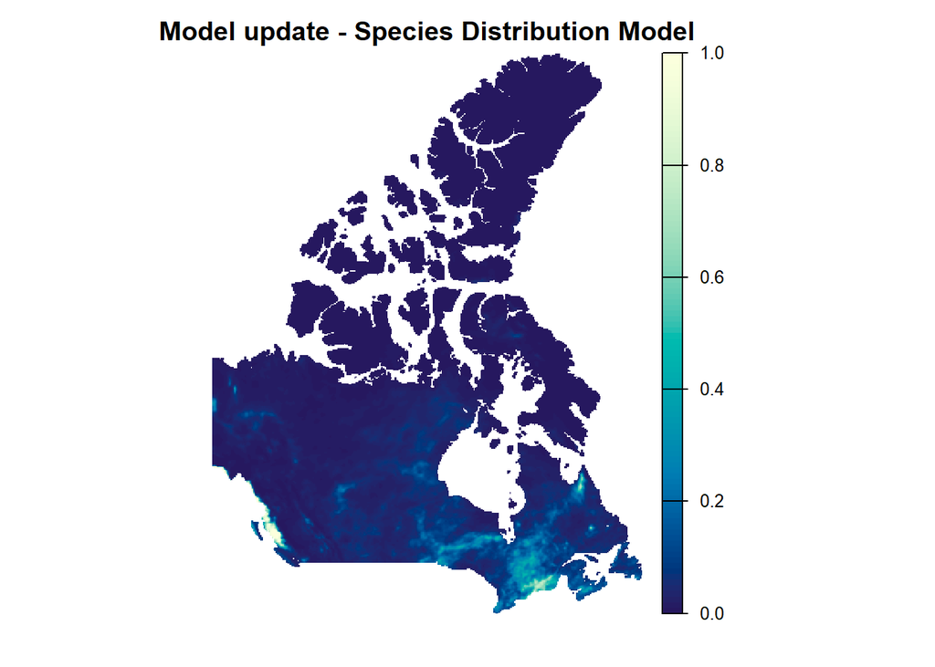

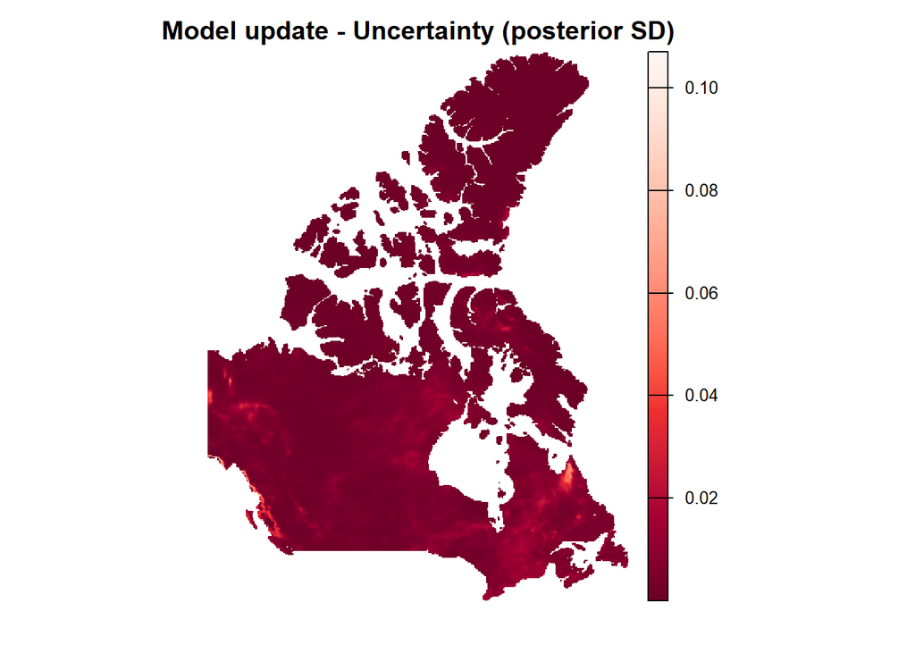

```r
plot_sim_maps(sim_70$ei_mean, sim_70$ei_sd,
              title_pred = "Model update - Species Distribution Model",
              title_sd   = "Model update - Uncertainty (posterior SD)")
```

### Non-informative priors: replicate-averaged maps

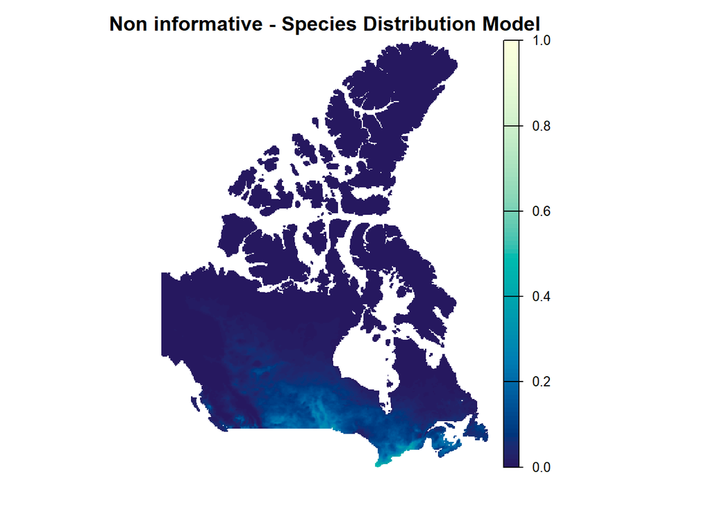

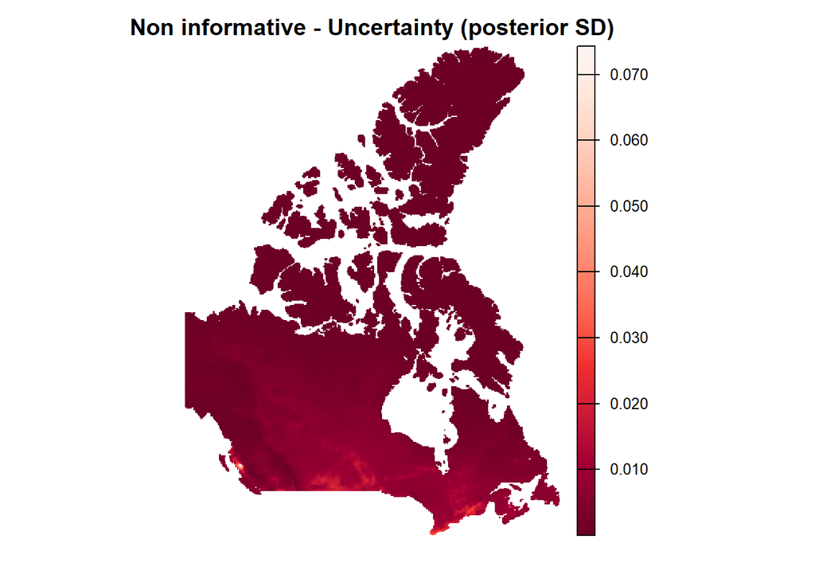

```r
plot_sim_maps(sim_70$ni_mean, sim_70$ni_sd,
              title_pred = "Non informative - Species Distribution Model",
              title_sd   = "Non informative - Uncertainty (posterior SD)")
```

## 90 % removal

Runs the Step-2 pipeline 100 times on independent 90 % thinned draws and averages the prediction and SD maps across replicates.

```r
removal_pct     <- 90
removal_pct_txt <- gsub("\\.", "_", as.character(removal_pct))

sim_90 <- run_thinning_replicates(monarch_sf0, removal_pct, n_rep = n_rep)
```

### Expert-informed priors: replicate-averaged maps

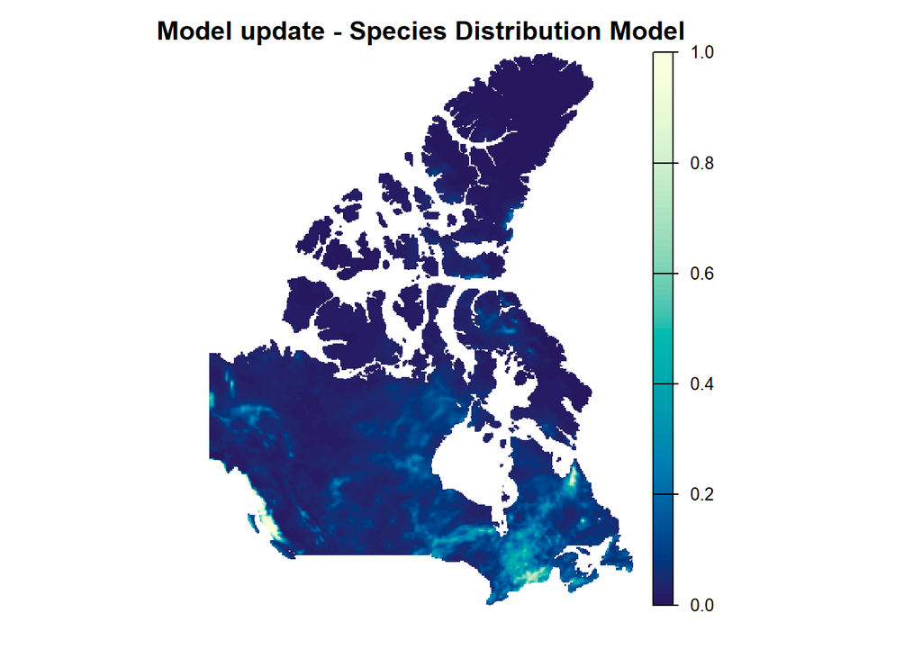

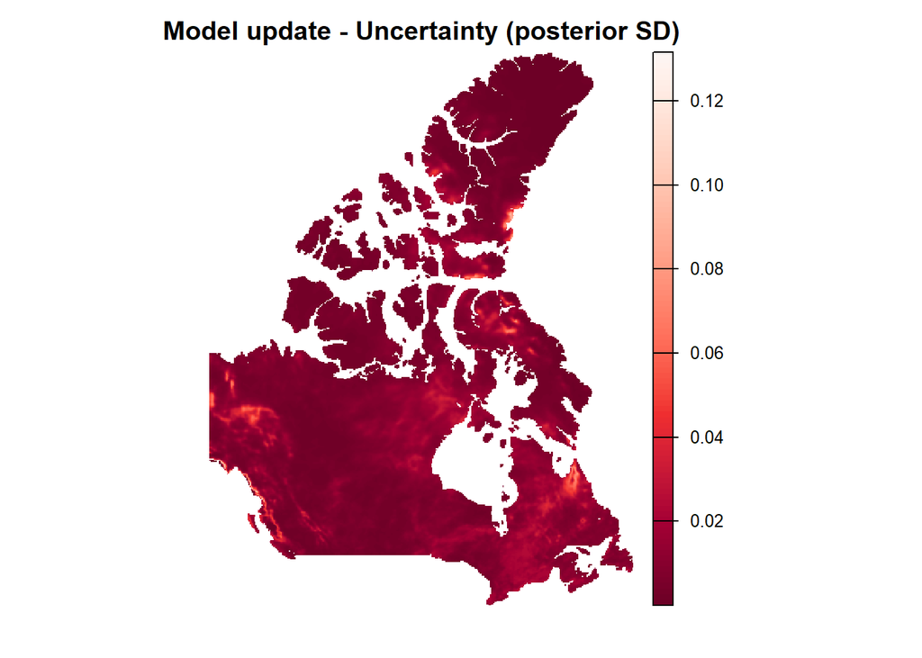

```r
plot_sim_maps(sim_90$ei_mean, sim_90$ei_sd,
              title_pred = "Model update - Species Distribution Model",
              title_sd   = "Model update - Uncertainty (posterior SD)")
```

### Non-informative priors: replicate-averaged maps

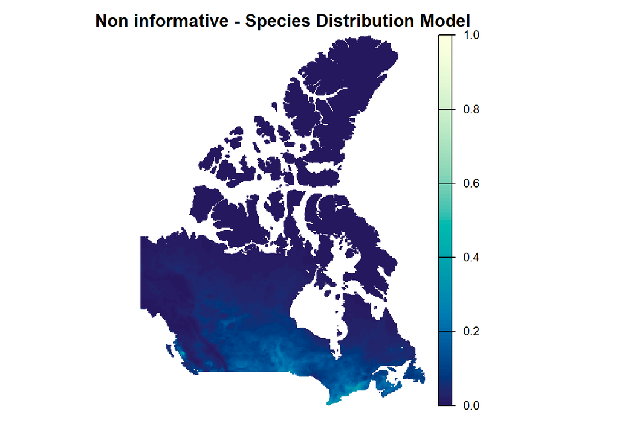

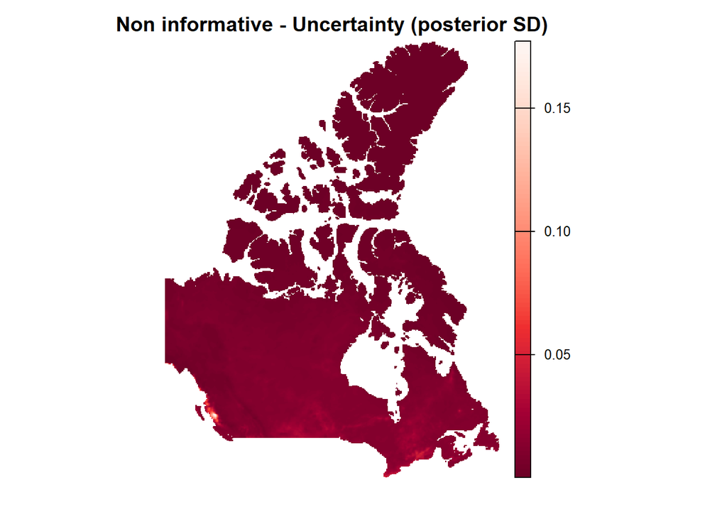

```r
plot_sim_maps(sim_90$ni_mean, sim_90$ni_sd,
              title_pred = "Non informative - Species Distribution Model",
              title_sd   = "Non informative - Uncertainty (posterior SD)")
```

## 99 % removal

Runs the Step-2 pipeline 100 times on independent 99 % thinned draws and averages the prediction and SD maps across replicates.

```r
removal_pct     <- 99
removal_pct_txt <- gsub("\\.", "_", as.character(removal_pct))

sim_99 <- run_thinning_replicates(monarch_sf0, removal_pct, n_rep = n_rep)
```

### Expert-informed priors: replicate-averaged maps

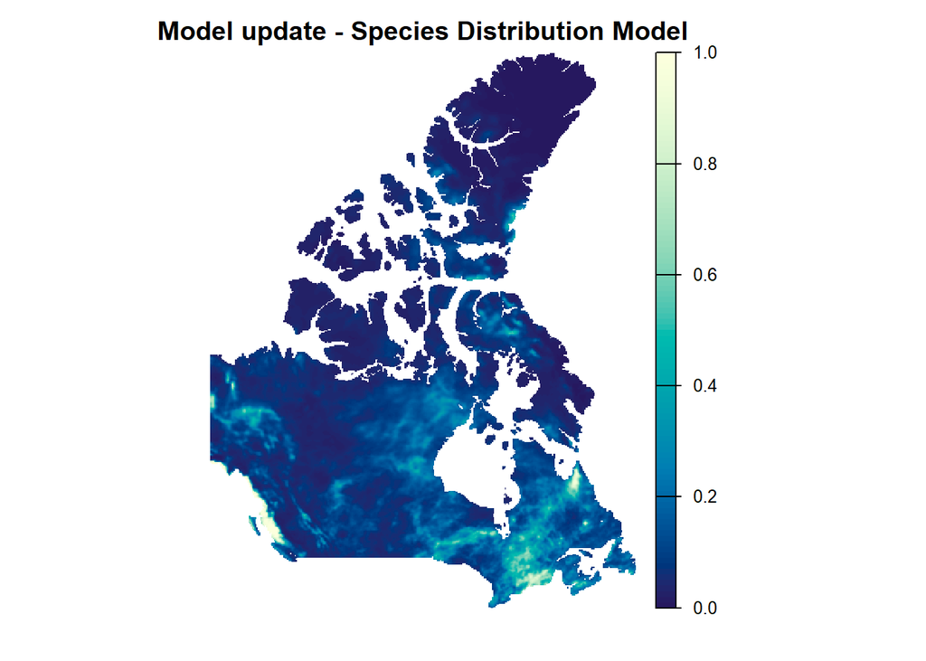

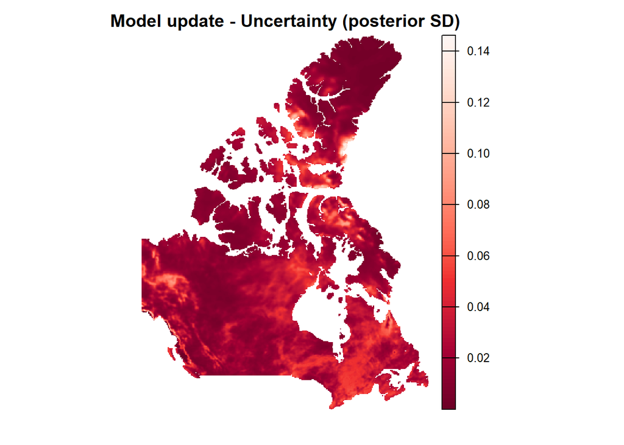

```r
plot_sim_maps(sim_99$ei_mean, sim_99$ei_sd,
              title_pred = "Model update - Species Distribution Model",
              title_sd   = "Model update - Uncertainty (posterior SD)")
```

### Non-informative priors: replicate-averaged maps

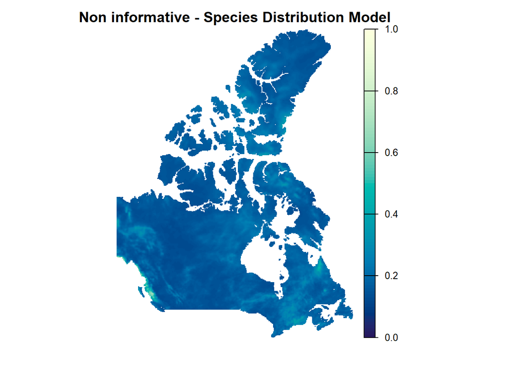

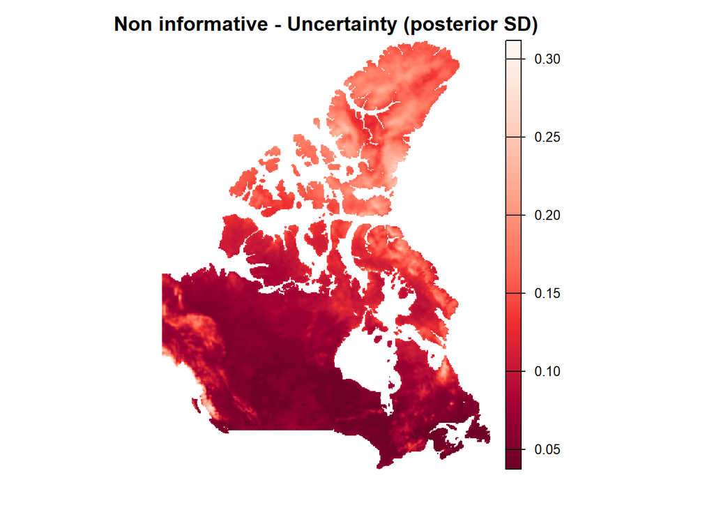

```r
plot_sim_maps(sim_99$ni_mean, sim_99$ni_sd,
              title_pred = "Non informative - Species Distribution Model",
              title_sd   = "Non informative - Uncertainty (posterior SD)")
```

## 99.9 % removal

Runs the Step-2 pipeline 100 times on independent 99.9 % thinned draws and averages the prediction and SD maps across replicates.

```r
removal_pct     <- 99.9
removal_pct_txt <- gsub("\\.", "_", as.character(removal_pct))

sim_999 <- run_thinning_replicates(monarch_sf0, removal_pct, n_rep = n_rep)
```

### Expert-informed priors: replicate-averaged maps

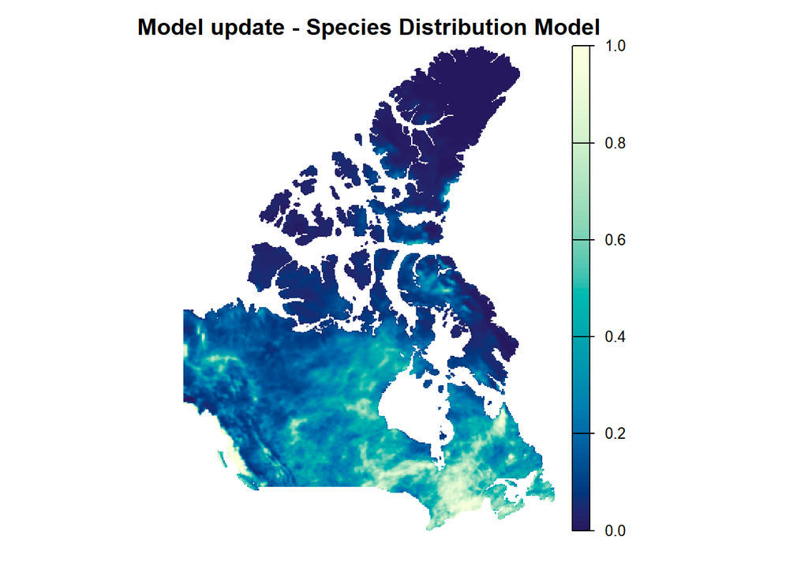

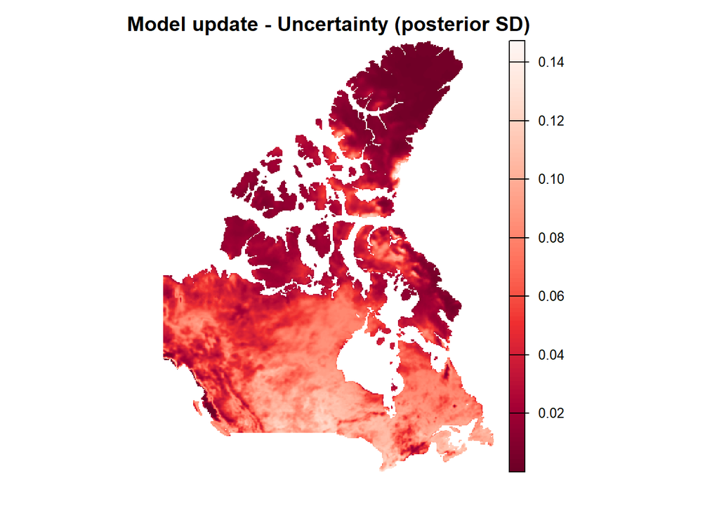

```r
plot_sim_maps(sim_999$ei_mean, sim_999$ei_sd,
              title_pred = "Model update - Species Distribution Model",
              title_sd   = "Model update - Uncertainty (posterior SD)")
```

### Non-informative priors: replicate-averaged maps

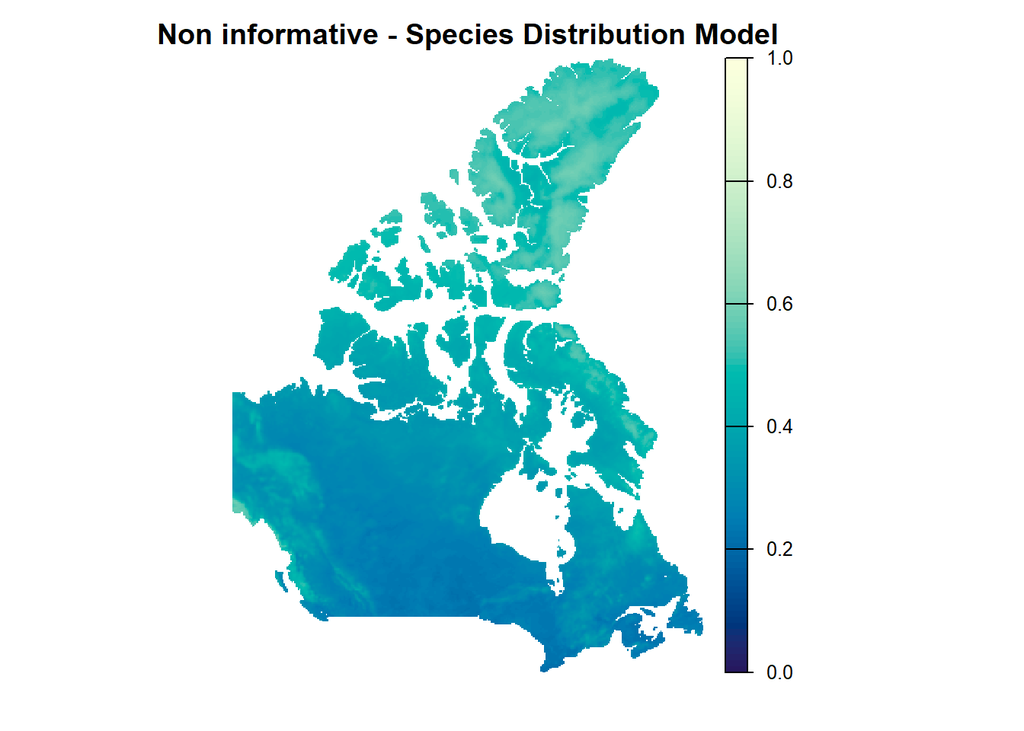

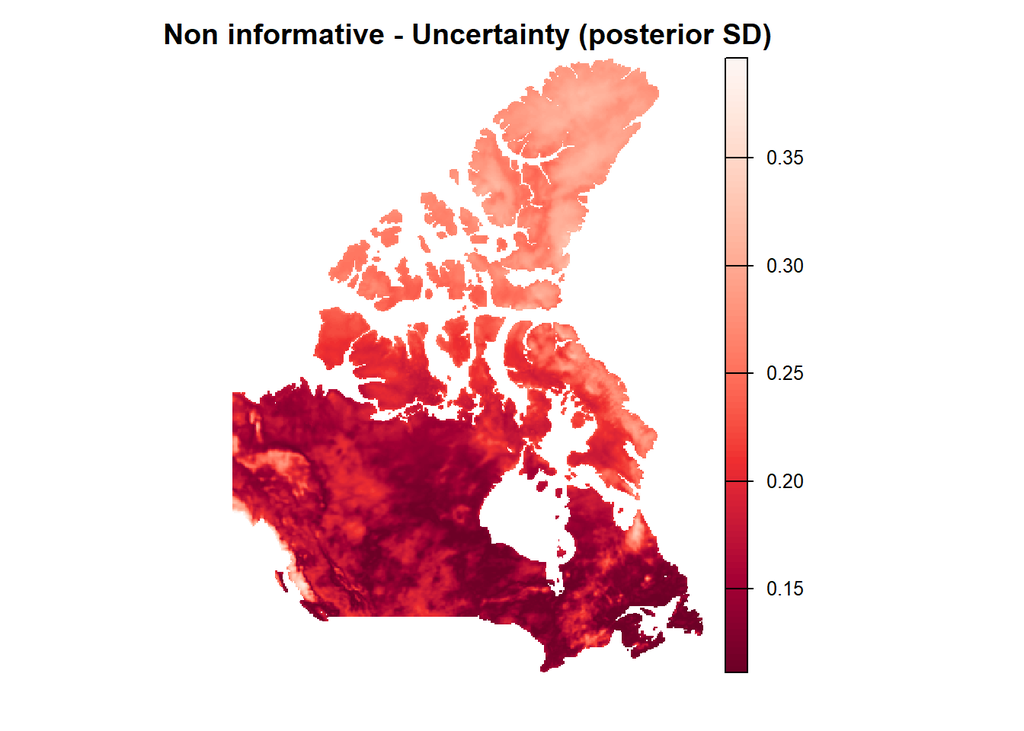

```r
plot_sim_maps(sim_999$ni_mean, sim_999$ni_sd,
              title_pred = "Non informative - Species Distribution Model",
              title_sd   = "Non informative - Uncertainty (posterior SD)")
```